# Laboratorium 4

Martyna Konopacka

### Zadanie 1

W tym zadaniu sprawdzamy, jak duża jest różnica, gdy konstruując przedział dla nieznanego $\sigma$ użyjemy kwantyli rozkładu normalnego, zamiast t-Studenta. Przeprowadziłam najpierw eksperymenty z liczbą iteracji $200$, jednak kiedy powtórzyłam je kilkukrotnie, zauważyłam duże wahania w wynikach wynikające z losowości i powtórzyłam eksperyment dla $1000$ losowań. Sprawdziłam dodatkowo też próby rozmiaru $n = 50$.

```r
glob_iter = 200
# Funkcja zwracające prawy przedziały ufności oparte na: 1.rozkładzie normalnym z szacowaniem sigma 2.rozkładzie Studenta (X - próba)
interval1 <- function(X, opt = 1, lvl = 0.95){
  alpha <- 1 - lvl
  X_ <- mean(X)
  n <- length(X)
  s <- sd(X)
  if (opt == 1){a <- qnorm(1 - alpha/2)}
  if (opt == 2){a <- qt(1 - alpha/2, n-1)}
  expr <- a*s/sqrt(n)
  return (c(X_ - expr, X_ + expr))
}

# Funkcja losująca próbę rozmiaru n z rozkładu normalnego N(mu,si) iter razy i sprawdzająca jak często prawdziwe mu zawiera się w przedziale ufności; Szacowanie przez `opt`: 1 - rozkład normalny 2 - rozkład Studenta
experiment1 <- function(n = 10, opt = 1, iter = glob_iter, lvl = 0.95, mu = 0, si = 1){
  inside <- 0
  for (i in 1:iter){
    X <- rnorm(n, mu, si)
    interval <- interval1(X, opt, lvl)
    if (between(mu, interval[1], interval[2])){inside <- inside + 1}
  }
  return(data.frame(
    mu = mu,
    si = si,
    n = n,
    opt = opt,
    inside = inside/iter,
    lvl = lvl,
    iter = iter
  ))
}
```

Podsumowanie wyników w zadaniu 1

| mu | si | n | opt | inside | lvl | iter |
| --- | --- | --- | --- | --- | --- | --- |
| 0 | 1 | 10 | 1 | 0.895 | 0.95 | 200 |
| 0 | 1 | 10 | 2 | 0.925 | 0.95 | 200 |
| 0 | 1 | 50 | 1 | 0.940 | 0.95 | 200 |
| 0 | 1 | 50 | 2 | 0.940 | 0.95 | 200 |
| 0 | 1 | 100 | 1 | 0.910 | 0.95 | 200 |
| 0 | 1 | 100 | 2 | 0.940 | 0.95 | 200 |
| 0 | 1 | 10 | 1 | 0.925 | 0.95 | 1000 |
| 0 | 1 | 10 | 2 | 0.948 | 0.95 | 1000 |
| 0 | 1 | 50 | 1 | 0.946 | 0.95 | 1000 |
| 0 | 1 | 50 | 2 | 0.950 | 0.95 | 1000 |
| 0 | 1 | 100 | 1 | 0.959 | 0.95 | 1000 |
| 0 | 1 | 100 | 2 | 0.949 | 0.95 | 1000 |

Można zauważyć, że gdy $n$ jest małe, przybliżenie rozkładem normalnym jest dużo gorsze niż rozkładem Studenta. W miarę ze wzrostem liczebności próby rozkłady coraz bardziej zbliżają się do siebie, więc błąd przybliżenia maleje.

### Zadanie 2

W tym zadaniu zakładamy, że dane pochodzą z pewnej populacji - nie znamy więc parametru $\sigma$ i używamy szacowania z użyciem rozkładu Studenta z zadania 1.

Wyniki dla zmiennej IQ

| lvl | low | high | width |
| --- | --- | --- | --- |
| 0.99 | 104.9842 | 112.8619 | 7.877736 |
| 0.95 | 105.9535 | 111.8927 | 5.939191 |
| 0.90 | 106.4402 | 111.4060 | 4.965748 |
| 0.80 | 106.9953 | 110.8508 | 3.855486 |
| 0.70 | 107.3669 | 110.4792 | 3.112265 |
| 0.60 | 107.6610 | 110.1852 | 2.524249 |
| 0.50 | 107.9124 | 109.9337 | 2.021302 |

Wyniki dla zmiennej TestPsych

| lvl | low | high | width |
| --- | --- | --- | --- |
| 0.99 | 53.24958 | 60.67350 | 7.423922 |
| 0.95 | 54.16301 | 59.76006 | 5.597051 |
| 0.90 | 54.62170 | 59.30138 | 4.679685 |
| 0.80 | 55.14485 | 58.77823 | 3.633382 |
| 0.70 | 55.49505 | 58.42803 | 2.932976 |
| 0.60 | 55.77212 | 58.15096 | 2.378834 |
| 0.50 | 56.00911 | 57.91397 | 1.904860 |

### Zadanie 3

W tym zadaniu porównujemy dwa sposoby konstrukcji przedziału ufności dla frakcji: metodę klasyczną (opisaną w poprzednim raporcie) i metodę Agrestiego-Coulla. Wg. wykładu klasyczny przedział ufności może zawodzić, gdy liczba sukcesów jest bliska $0$ lub $n$ - tzn. gdy prawdziwy parametr frakcji $p$ jest blisko $0$ lub $1$.

**Przedział ufności Agrestiego-Coulla**

Wprowadzamy następujące modyfikacje:

```r
# Funkcja zwraca lewy i prawy brzeg przedziału ufności dla p; V powinien być wektorem TRUE / FALSE;
# opt: 1 - klasyczny, 2 - Agrestiego-Coulle
przedzial_p <- function(V, opt = 1, poziom = 0.95){
  n <- length(V)
  u <- qnorm(p = 1 - (1-poziom)/2)
  if (opt == 1){
    p <- sum(V)/length(V) # środek przedziału
    SE <- sqrt((p*(1-p)/n)) # błąd standardowy
  }
  if (opt == 2){
    Y <- sum(V)
    p <- (Y + 0.5 * u^2)/(n + u^2) # środek przedziału
    SE <- sqrt((p*(1-p)/(n+ 0.5 * u^2))) # błąd standardowy
  }
  return(c(p - u*SE, p+ u*SE))
}

# Funkcja zwraca estymator punktowy p w oparciu o wektor V (TRUE/FALSE); opt: 1 - klasycznie, 2 - Agrestiego-Coulle na poziomie lvl
estim_p <- function(V, opt = 1, lvl = 0.95){
  n = length(V)
  if (opt == 1){
    return(sum(V)/n)
    }
  else if (opt == 2){
    u = qnorm(1 - (1-lvl)/2)
    return ( (sum(V) + 0.5 * u^2)/(n + u^2) )
}
}
```

Porównanie wyników w zadaniu 3

| estymator | n | iter | pw_width | pk_width | pp_width | pw_percent | pk_percent | pp_percent |
| --- | --- | --- | --- | --- | --- | --- | --- | --- |
| klasyczny | 200 | 200 | 24.52108 | 27.68047 | 20.07156 | 0.990 | 1.000 | 0.990 |
| A-C | 200 | 200 | 24.48832 | 27.54698 | 20.29797 | 0.995 | 0.995 | 0.995 |

Oba estymatory dają porównywalne wyniki. Poniżej histogramy estymatorów punktowych otrzymanych dwoma sposobami.

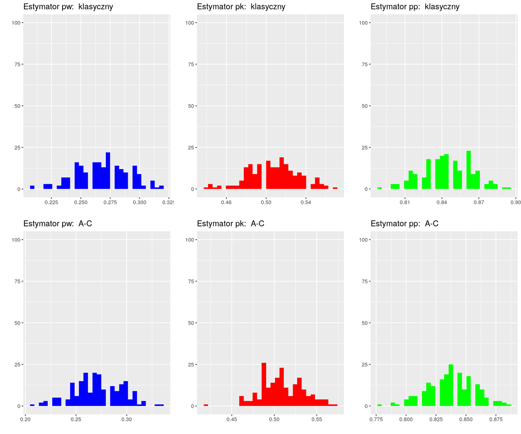

### Dodatkowe eksperymenty do zadania 3

Przeprowadziłam dodatkowe eksperymenty w celu sprawdzenia, czy różnica pomiędzy metodami będzie widoczna w testach na próbie, dla której liczba sukcesów jest bliska $0$ lub $n$.

```r
experiment2b <- function(real_p = 0.5, opt = 1, n = 200, iter = 1000, lvl = 0.95){
  name <- ifelse(opt == 1, 'klasyczny', 'A-C')
  # Funkcja zwraca listę z histogramem i dataframe wyników jak w zadaniu 3 ale dla prób z rozkładu Bernoulliego z dowolnym p
  # wektor na estymatory punktowe
  p <- numeric(iter)

  # liczniki jak często przedział zawiera prawdziwy parametr
  p_count <- 0

  # skumulowane szerokości przedziałów
  p_w <- 0

  for (i in 1:iter){
    X <- rbernoulli(n, real_p)

    # zapisanie estymatora punktowego
    p[i] <- estim_p(X, opt, lvl)

    # wyznaczanie przedziałów
    I <- przedzial_p(X, opt, lvl)

    # dodanie ich szerokości
    p_w <- p_w + I[2] - I[1]

    # sprawdzenie czy zawierają prawdziwy parametr (frakcję w całym zbiorze income)
    if (between(real_p, I[1], I[2])){p_count <- p_count + 1}

  }
  # tworzenie histogramu
  hist <- qplot(p, xlab = '', geom = 'histogram', main = paste('Estymator p: ', name), fill = I('Blue'))

  # tworzenie podsumowania
  summar <- data.frame(
    p = real_p,
    lvl = lvl,
    estymator = name,
    n = n,
    iter = iter,
    mean_width = mean(p_w),
    p_percent = sum(p_count)/iter
  )
  return (summar = summar)
}

results_extr <- rbind(experiment2b(0.005), experiment2b(0.005, opt = 2), experiment2b(0.01), experiment2b(0.02), experiment2b(0.1), experiment2b(0.9), experiment2b(0.95), experiment2b(0.99),
                      experiment2b(0.01, opt = 2), experiment2b(0.02, opt = 2), experiment2b(0.1, opt = 2), experiment2b(0.9, opt = 2), experiment2b(0.95, opt = 2), experiment2b(0.99, opt = 2))

results_extr[order(results_extr$p), ] %>% mutate(rel_difference = (lvl - p_percent)/lvl) %>% knitr::kable(caption = 'Dodatkowe eksperymenty w zadaniu 3 - wyniki')
```

Dodatkowe eksperymenty w zadaniu 3 - wyniki

| p | lvl | estymator | n | iter | mean_width | p_percent | rel_difference |
| --- | --- | --- | --- | --- | --- | --- | --- |
| 0.005 | 0.95 | klasyczny | 200 | 1000 | 14.46720 | 0.615 | 0.3526316 |
| 0.005 | 0.95 | A-C | 200 | 1000 | 32.69999 | 0.974 | -0.0252632 |
| 0.010 | 0.95 | klasyczny | 200 | 1000 | 24.40830 | 0.860 | 0.0947368 |
| 0.010 | 0.95 | A-C | 200 | 1000 | 36.99141 | 0.985 | -0.0368421 |
| 0.020 | 0.95 | klasyczny | 200 | 1000 | 37.17279 | 0.904 | 0.0484211 |
| 0.020 | 0.95 | A-C | 200 | 1000 | 45.28102 | 0.990 | -0.0421053 |
| 0.100 | 0.95 | klasyczny | 200 | 1000 | 81.99883 | 0.918 | 0.0336842 |
| 0.100 | 0.95 | A-C | 200 | 1000 | 84.98746 | 0.952 | -0.0021053 |
| 0.900 | 0.95 | klasyczny | 200 | 1000 | 82.31351 | 0.924 | 0.0273684 |
| 0.900 | 0.95 | A-C | 200 | 1000 | 84.95583 | 0.940 | 0.0105263 |
| 0.950 | 0.95 | klasyczny | 200 | 1000 | 59.49809 | 0.926 | 0.0252632 |
| 0.950 | 0.95 | A-C | 200 | 1000 | 63.89010 | 0.974 | -0.0252632 |
| 0.990 | 0.95 | klasyczny | 200 | 1000 | 24.56072 | 0.856 | 0.0989474 |
| 0.990 | 0.95 | A-C | 200 | 1000 | 37.18484 | 0.987 | -0.0389474 |

W ostatniej kolumnie tabeli widać błąd względny pomiędzy odsetkiem parametrów w przedziale teoretycznym, a wyznaczonym. Dla skrajnych wartości $p$ (tj. mniejszych od 0.01 lub większych od 0.99) klasyczna metoda rzeczywiście daje wyniki wyraźnie gorsze niż metoda Agrestiego-Coull'a. Dodatkowo można zauważyć, że wszystkie ujemne wartości w tej kolumnie pochodzą z estymacji metodą A-C (są to przypadki, gdzie oszacowany przedział zawiera więcej obserwacji prawdziwego parametru niż powinien, tzn. jest za szeroki.)